# Precip Golden Data

Derek Smith

Tuesday, January 26, 2016

# Overview of precipitation golden data

The golden data set was created with the following inputs

- A seed 1234.
- An initial bucket starting point of 997 mm.
- A high intensity rain event.
- The size of the golden data set in terms of the number of 5 minute averages is 1000. The first two hours of the data are used to initialize the algorithm and therefore are not processed in these results.
- Gauge nosie was set to medium using seed 1234 for gauge 1, medium using seed 2345 for gauge 2, and low using seed 3456 for gauge 3.
- There are 30 gaps throughout the data set of 0.1 Hz data ranging in size from 20 to 100.

# Results

The were 8 of precipitation events totaling 4.36 mm in the dataset.

### Overview of quality flag results

Quality flag results are presented below by both the number of failures for a given quality flag as well as the percent of failures over the entire data set.

[output not shown]

## Plots

The plot below shows where the exDeltaQF failed. The vertical line indicates where the flag was set to 1, which was due to a simulated bucket emptying event.

The extreme delta quality flag indicates when precipitation could not be calculated for one or more of the strain gauges because the difference between the current and previous depth measurements for a given strain gauge was too extreme large. This is an indication of an erroneous measurement that may arise for a number of reasons, e.g., broken wire, gauge emptying, and wind pumping.

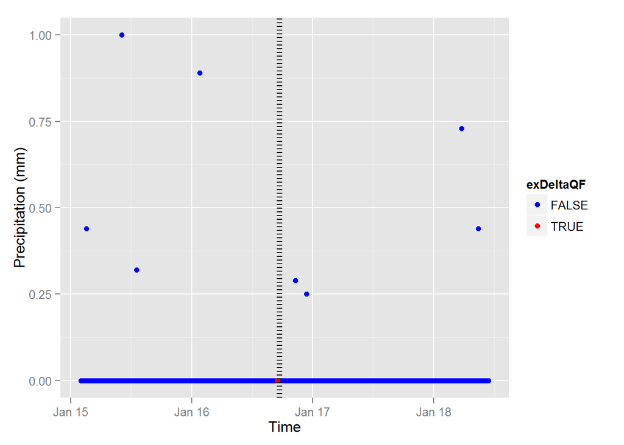

The plot below shows the status of the missingWireInfoQF troughout the data set. The missing wire information flag indicates when precipitation could not be calculated for a time period because two or more of the strain gauges had invalid measurements.

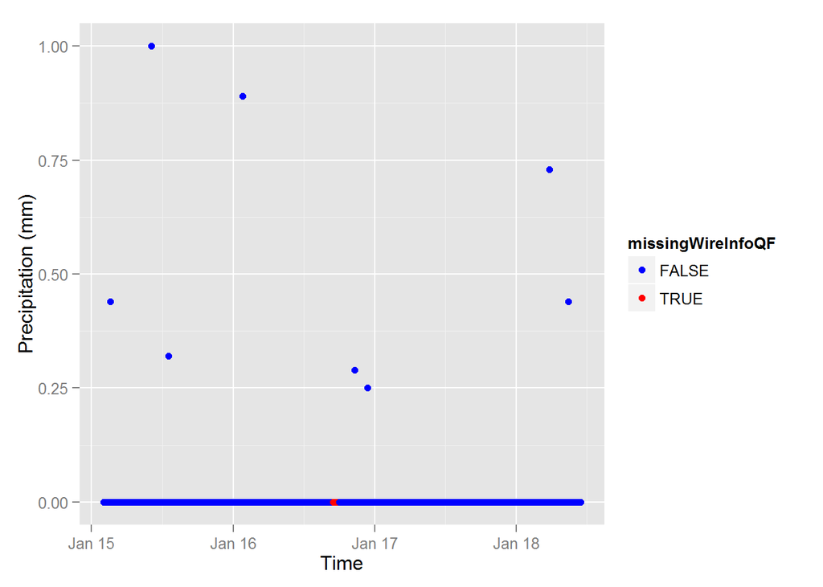

The plot below shows the status of the gaugeNoiseQF troughout the data set. The gauge noise quality flag indicates when precipitation was set to zero for a time period because the difference among the individual strain gauge measurements was too large for the given time interval.

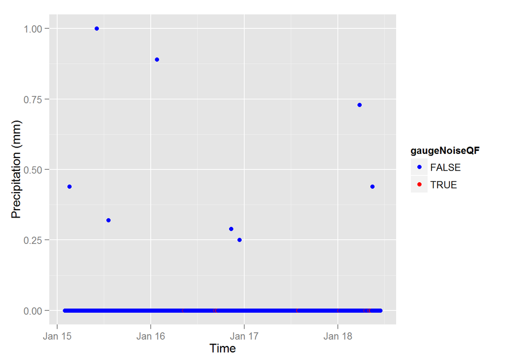

The plot below shows the status of the wireNoiseQF troughout the data set. The wire noise quality flag indicates when precipitation was set to zero for a time period because one or more of the strain gauges depth change was negative over the time interval.

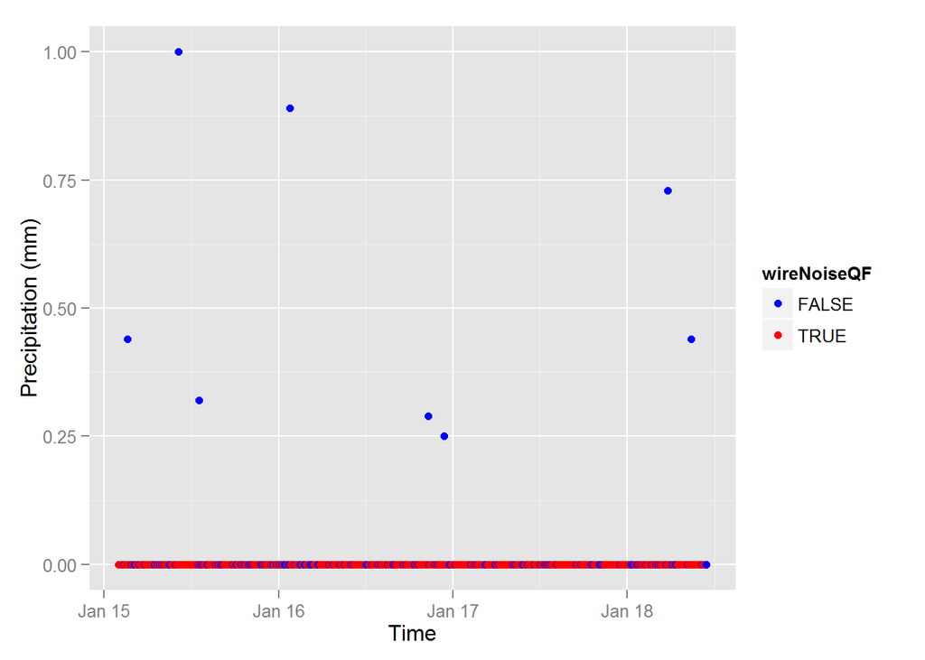

The plot below shows where the overflowQF failed. The vertical line indicates where the flag was set to 1, which was due to a simulated overflowing bucket.

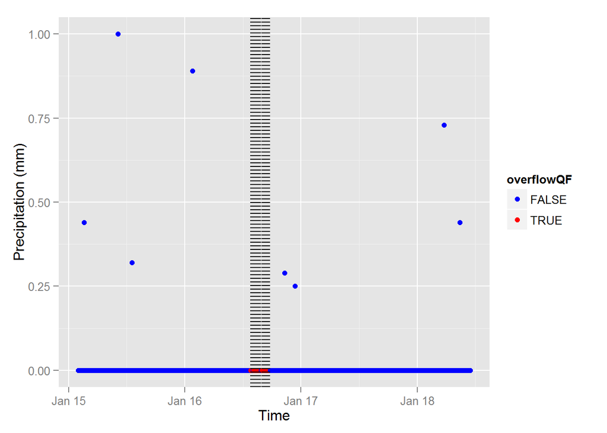

The plot below shows the status of the priorDepthQF troughout the data set. The prior depth quality flag indicates when precipitation could not be calculated for a time period because the two previous depth measurements were missing for two or more of the strain gauges.

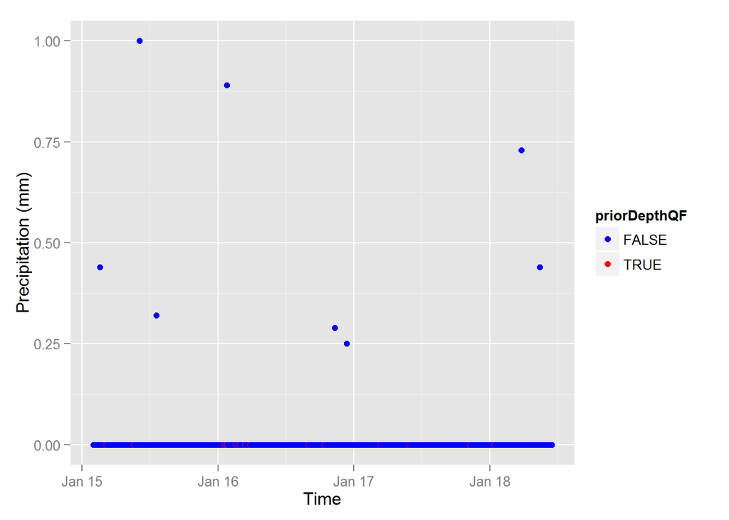

The plot below shows the status of the nullQF troughout the data set.

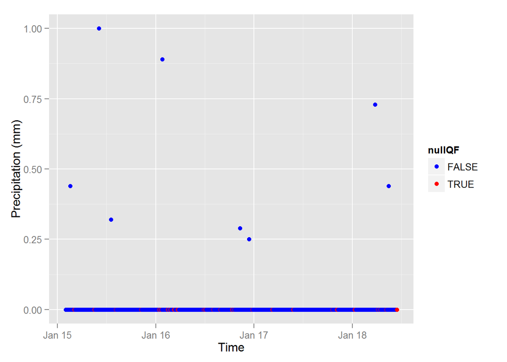

[output not shown]

```
##                time        delta1        delta2        delta3
## N                NA  9.720000e+02  9.720000e+02  9.720000e+02
## mean             NA -1.024954e+00 -1.024665e+00 -1.024242e+00
## Std.Dev.         NA  3.208911e+01  3.208992e+01  3.208721e+01
## min              NA -1.000424e+03 -1.000449e+03 -1.000374e+03
## Q1               NA -8.504063e-02 -9.079841e-02 -8.827239e-03
## median           NA  0.000000e+00  0.000000e+00  0.000000e+00
## Q3               NA  8.708025e-02  9.080861e-02  8.993938e-03
## max              NA  1.195639e+00  9.607699e-01  9.251341e-01
## missing values   NA  0.000000e+00  0.000000e+00  0.000000e+00
##                    intPrecip lowDepthQF    exDeltaQF missingWireInfoQF
## N              972.000000000        972 972.00000000      972.00000000
## mean             0.004630918          0   0.01234568        0.01234568
## Std.Dev.         0.076442360          0   0.11047996        0.11047996
## min             -0.184624387          0   0.00000000        0.00000000
## Q1              -0.028270294          0   0.00000000        0.00000000
## median           0.000000000          0   0.00000000        0.00000000
## Q3               0.028118179          0   0.00000000        0.00000000
## max              0.999732121          0   1.00000000        1.00000000
## missing values   0.000000000          0   0.00000000        0.00000000
##                       gapQF priorDepthQF  overflowQF     adjPrecip
## N              972.00000000 972.00000000 972.0000000 972.000000000
## mean             0.04938272   0.01646091   0.0462963   0.004881576
## Std.Dev.         0.21677733   0.12730521   0.2102342   0.076222133
## min              0.00000000   0.00000000   0.0000000  -0.184624387
## Q1               0.00000000   0.00000000   0.0000000  -0.027358639
## median           0.00000000   0.00000000   0.0000000   0.000000000
## Q3               0.00000000   0.00000000   0.0000000   0.028118179
## max              1.00000000   1.00000000   1.0000000   0.999732121
## missing values   0.00000000   0.00000000   0.0000000   0.000000000
##                gaugeNoiseQF   radjPrecip wireNoiseQF roundedPrecip
## N              972.00000000 972.00000000 972.0000000  972.00000000
## mean             0.01131687   0.01148860   0.8148148    0.01150206
## Std.Dev.         0.10583158   0.06349454   0.3886477    0.06339199
## min              0.00000000   0.00000000   0.0000000    0.00000000
## Q1               0.00000000   0.00000000   1.0000000    0.00000000
## median           0.00000000   0.00000000   1.0000000    0.00000000
## Q3               0.00000000   0.00000000   1.0000000    0.00000000
## max              1.00000000   0.99973212   1.0000000    1.00000000
## missing values   0.00000000   0.00000000   0.0000000    0.00000000
##                detectablePrecip  finalPrecip
## N                  9.720000e+02 9.720000e+02
## mean               5.298354e-03 4.485597e-03
## Std.Dev.           6.053328e-02 5.504088e-02
## min                0.000000e+00 0.000000e+00
## Q1                 0.000000e+00 0.000000e+00
## median             0.000000e+00 0.000000e+00
## Q3                 0.000000e+00 0.000000e+00
## max                1.000000e+00 1.000000e+00
## missing values     0.000000e+00 0.000000e+00
```